# 6 Approximate derivatives in Julia

A notebook for this material: ipynb

## 6.1 Introduction

We load our packages to begin.

```julia
using MTH229
using Plots
plotly()
```

Single-variable calculus has two main concepts: the derivative and the integral, both defined in terms of a third important concept: the limit. The derivative is what we discuss here.

The derivative allows us to formally talk about a tangent line to a curve. This is often called a line that touches the curve at just one point, but that isn’t quite correct, though often the case locally. A better idea would be to say it is the line that best approximates the curve at that point. That is, if we were to zoom in to the graph it might appear to look straight, and that straightness would have a slope that would match the tangent line. This idea leads to a primary use of the derivative—to approximate functions with simpler lines. Of course, this intuition is informal, a definition is in terms of the slope of approximating secant lines.

Historically, Fermat, in a treatise on finding maxima and minima, approached the problem of finding the tangent line by comparing the value of $f(x)$ to a nearby value $f(x+h)$. Working with polynomials, meant that subtracting $f(x+h) - f(x)$ led to a polynomial in $h$. Dividing by $h$ and then setting $h=0$ yields an answer for the slope.

The more modern approach (well Cauchy in the 1820s) defines the derivative of a function, $f$, at a point $c$ as the slope of the *tangent line*, defined in terms of the *limit* of the slopes of approximating secant lines. The notation is:

$$f'( c ) = \lim_{h \rightarrow 0} \frac{f(c + h) - f( c)}{h}.\quad\text{Derivative at a point}$$

As mentioned, intuitively, the tangent line is the best straight-line approximation to a function near the point $(c, f( c))$ and would have slope given by the derivative.

This graph shows $f(x) = 2 - x^2$ and various secant lines when $c=-0.75$.

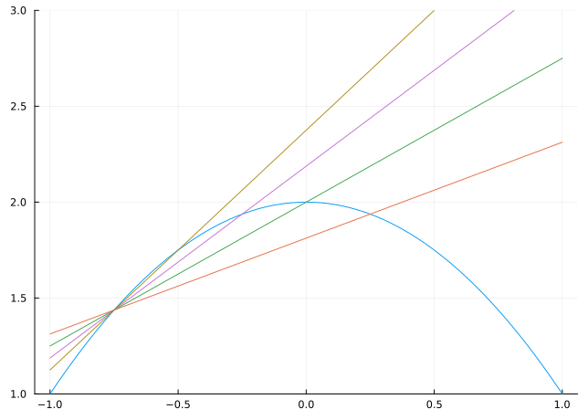

```julia
f(x) = 2 - x^2
c = -0.75
slh(h) = secant(f, c, c+h)                # secant from the MTH229 package
plot(f, -1, 1, legend=false, ylim=(1,3))
plot!(secant(f, c, c + 1))
plot!(secant(f, c, c + 3/4))
plot!(secant(f, c, c + 1/2))
plot!(secant(f, c, c + 1/4))
```

As the value of $h$ goes towards 0 along the path $1$, $0.75$, $0.5$, $0.25$, … the slope of the secant line heads towards the slope of the tangent line, in this case $2\cdot 0.75 = 1.5$.

Using the idea of a derivative at a point, one defines the derivative of the function $f$ to be the function which for each $x$ returns the derivative of $f$ at the point $x$. Notationally, this just replaces $c$ above with $x$, but conceptually there is a bit more to it.

## 6.2 Forward difference quotients, Slope of the tangent line

The rules of derivatives allow for a mechanical approach to taking derivatives with the power rule, chain rule and some special cases. In this project we look at approaching the derivative numerically. We start by investigating *approximate derivatives* computed with *finite difference quotients*.

The most naive approximation is simply to assume $h$ is some small number and use that to approximate the limit above:

```julia
f(x) = x^2 - 2x
df(x) = 2x - 2
h = .001
c = 3
( f(c + h) - f(c) ) / h
```

```
4.000999999999699
```

This is known as the *forward difference quotient* approximation to the derivative. For this example, the difference between the approximation and the actual slope is:

```julia
( f(c + h) - f(c) ) / h - df(c)
```

```
0.0009999999996992415
```

That is not too close, just to 3 digits of accuracy.

Notationally, we may write this as:

$$f'( c) \approx \frac{f(c + h) - f( c) }{h}$$

For some small value of $h$. The equals sign is replaced by an approximation symbol, as there is no limit expression written.

##### Example Derivative at a point

Let’s try the derivative of some well known function. We know the derivative of $f(x) = \sin(x)$ is $f'(x) = \cos(x)$. Let’s see if the above works well:

```julia
f(x) = sin(x)
df(x) = cos(x)
c = pi/4; h = 0.0001
( f(c + h) - f(c) )/h - df(c)
```

```
-3.535651724428934e-5
```

Not as good as we can get—the error is like `1e-5`, but not too bad already.

##### Example Finding profit

Suppose the tractor company John Deere models its profit per units sold through the function $P(x) = 50 e^{x/250}/(1 - e^{x/250})$. Find the marginal profit for $x=200$.

The marginal profit is the change in profit per unit sold—or the derivative—at $x=200$.

We can find this quite simply by either differentiating directly, or as we do here, approximating the answer with `Julia`. We first note that the function above, is a composition, so it may be written using two functions:

```julia
f1(x) = exp(x)/(1 - exp(x))
f(x) = 50 * f1(x/250)
c = 200; h = 0.0001;
res = (f(c+h) - f(c))/h
```

```
0.29635326299626286
```

If $50$ is the maximum profit, this is a percentage increase of:

```julia
(res/50) * 100
```

```
0.5927065259925257
```

or a bit more than half a percent.

##### Example Finding the tangent line at a point

Let $f(x) = x^x$. Find the tangent line at $c=2$. Compare the difference between the value of the tangent line and the function at $x=2.1$.

The tangent line is most easily expressed in terms of the *point-slope* formula for a line where the point is $(c, f( c))$ and the slope is $f'( c)$. This gives:

$$y = f( c) + f'( c)\cdot(x - c)$$

In the following, the slope of the tangent line will be *approximated* using a numeric derivative. We use $h=0.0001$:

```julia
f(x) = x^x
c = 2; h = 0.0001
m = ( f(c + h) - f(c) ) / h
tangent_line(x) = f(c) + m * (x - c)
```

```
tangent_line (generic function with 1 method)
```

To compare the difference, we have:

```julia
f(2.1) - tangent_line(2.1)
```

```
0.07231187980696063
```

A graph shows this difference:

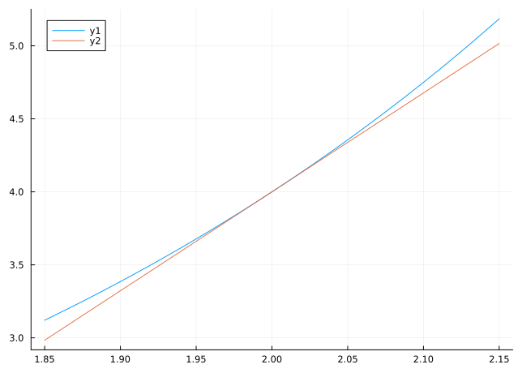

```julia
plot(f, 1.85, 2.15)
plot!(tangent_line)
```

### 6.2.1 Practice

#### Question

Find the slope of the tangent line of $f(x) = x\log(x)$ at the value $x=1$ using $h=0.0001$ and the forward difference quotient method:

#### Question

Find the slope of the tangent line of $f(x) = x-\log(x)$ at the value $x=1$ using $h=0.0001$ and the forward difference quotient method:

#### Question

The built-in `airyai` function, when called as `airyai(x)`, returns the so-called Airy function, a special function named after [George Biddell Airy](http://en.wikipedia.org/wiki/Airy_function).

Compute the derivative at $c=-3$ using $h=0.0001$.

#### Question

Let $f(x) = \sin(x)$. The slope of the tangent line at $c=\pi/4$ is well known to have slope $\sqrt{2}/2$.

Compute the forward difference quotient for $f$ at $c$ using $h=0.01$. What is the order of the difference between the two values?

3 parts in 100

3 parts in 1000

3 parts in 10,000

3 parts in 100,000

#### Question

For the function $f(x) = x^3 - 5x$ use a forward difference quotient with $h=0.0001$ to approximate the slope of the tangent line at $c=1$. Use this value to create a tangent line at `(c, f( c))`. Plot both the function and the tangent. Estimate graphically where the tangent line crosses the $x$ axis. The value is near:

-2.0

-1.5

-1.0

-0.5

0.0

1.0

## 6.3 Derivative of a function

We might be interested not in the derivative at a point, but in the derivative as a function. This is how we think of the derivative when we say if $f(x) = \sin(x)$, the $f'(x) = \cos(x)$. Mathematically, from this viewpoint, the derivative is referred to as an *operator*, as it takes a function and returns a function.

We can reproduce this behavior easily enough with `Julia`, as functions are *first class objects*: they can be passed as arguments and returned as values.

First, let’s define a function to find the derivative at a point using the “forward difference quotient”:

```julia
forward_difference(f, x0, h) = (f(x0 + h) - f(x0))/h
```

```
forward_difference (generic function with 1 method)
```

We need three arguments of course as we have three ingredients to worry about: the function, the point and the size of $h$.

To make an operator that takes $f$ and returns a function (an anonymous function in this case) that computes our approximation to $f'$ we can do the following:

```julia
Df(f; h=1e-8) = x -> forward_difference(f, x, h)
```

```
Df (generic function with 1 method)
```

We specified a default value of $h$ for convenience, but allow it to be varied if desired.

To see this work, we can find and plot the derivative of $\sin(x)$:

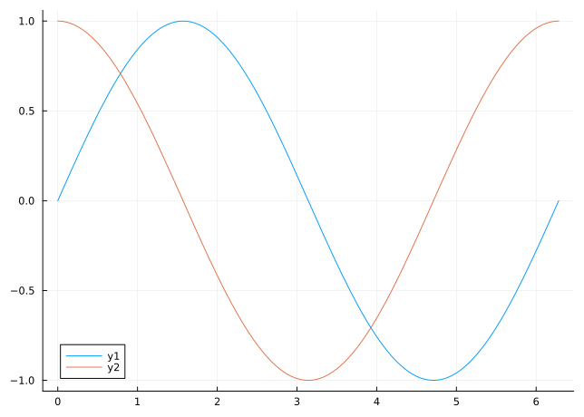

```julia
f(x) = sin(x)
fp = Df(f)
plot(f, 0, 2pi)
plot!(fp)
```

Well, we already knew that should just be $\cos(x)$. The point is we can easily make the an approximate derivative function from `f` with the definition `fp = Df(f)`.

**NoteDefining `fp` or `fp(x)`**

We could also have just plotted `f` and `Df(f)` without naming `fp`. As well, could have written `fp(x) = Df(f)(x)`, but that will use the global variable `f` everytime it is called. A reminder though, using `fp = Df(f)` and `fp(x) = ...` in the same session will error. To avoid this, we use `fp` for the former and `df` when the latter is desired.

Let’s look at a different function, where we don’t know in our heads the answer.

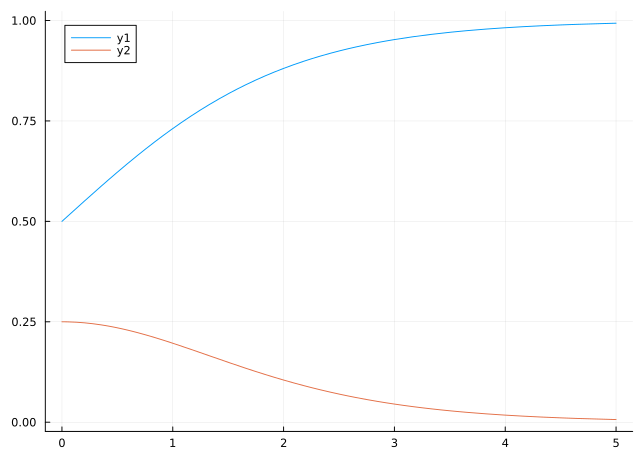

```julia
f(x) = exp(x)/(1 + exp(x))
plot(f, 0, 5)
plot!(Df(f))
```

If we look, we can see from the graph that `f` is increasing and `Df(f)` is positive—this is no coincidence, of course.

##### Example: Critical points

A function’s *critical points* are where its derivative is $0$ or undefined. We can examine these by graphing the function’s derivative. Let’s do so for the polynomial $f(x) = x^3 - 5x + 4$:

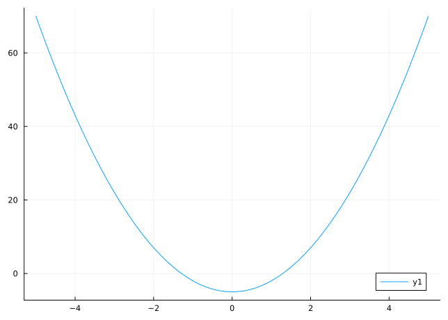

```julia
f(x) = x^3 -5x + 4
fp = Df(f)
plot(fp, -5, 5)
```

You can check the zeroes graphically, say by zooming in a bit and adding the line $y=0$:

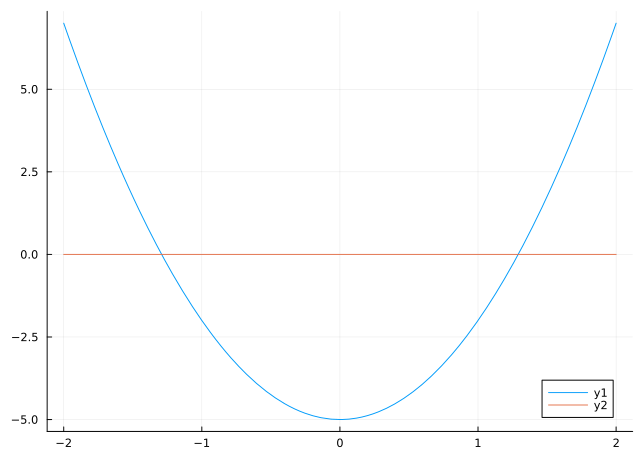

```julia
plot(fp, -2, 2)
plot!(zero)
```

If you want, we can find the roots numerically.

```julia
fzero(fp, -2, -1), fzero(f', 1, 2)
```

```
(-1.2909944653511047, 1.2909944487358056)
```

##### Example: When is a function increasing?

Let $f(x) = \cos(x)$ over the interval $[0, 360]$ (in degrees). When is the function increasing?

From the relationship of the derivative and the function, we know the answer is when $f'(x) > 0$. (This is formalized using the mean value theorem.) For this example, we can solve this directly as $f'(x) = -\sin(x)$ and we know when that is positive (well you are supposed to anyways: when the angle is in the third and fourth quadrants). Let’s see how we would do this task with `Julia` and compare.

First, we only need the derivative, so we just ask:

```julia
f(x) = cosd(x)          # using degrees
fp = Df(f)              # use default h
```

```
#3 (generic function with 1 method)
```

Then we wish to indicate on the graph where `fp(x) > 0`. We can do this by defining a function that is $0$ when that is the case and `NaN` otherwise (so that those points are not plotted). We do so below using the `plotif` function from the `MTH229` package

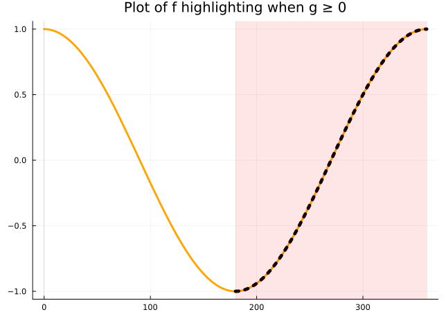

```julia
plotif(f, fp, 0, 360)  # second color when fp > 0
```

### 6.3.1 Practice

#### Question

Let $f(x) = e^x$. Using a forward difference quotient and $h=0.001$ graph both the function and its approximate derivative over the interval $[0, 3]$. Estimate graphically the largest difference between the function and its approximate derivative.

It is about 0.01

It is about 0.1

It is about 0

#### Question

Let $f(x) = x^2 \exp(-x)$. Using $h=0.0001$ and an approximate derivative, estimate graphically where $f'(x)$ is positive on the interval $[0,3]$.

Between 0 and 2

From 0 to about 0.45

It is for the entire interval

#### Question

The critical points of a function are where its derivative is undefined or where its derivative is $0$. For the function $f(x) = 3x^4 -28x^3 + 96x^2 - 144x$ graphically find any critical points over the interval $[0,10]$

There are two distinct ones: 2, 3

There is one at 3

There are two distinct ones: 2, 4.69

There are two distinct ones: 2, 2.6667

## 6.4 Improvements to the basic forward difference quotient

The error in the approximation of the derivative depends on the size of $h$. Mathematically, as $h$ gets smaller we get better approximations, though with the computer other complications arise. To see mathematically that this is the case, let’s look at the difference between the approximate numeric derivative from the forward difference quotient and a known derivative.

```julia
f(x) = sin(x)
df(x) = cos(x)
[ Df(f,h=h)(.5) - df(.5) for h=[.1, .01, .001, .0001, .00001] ]
```

```
5-element Vector{Float64}:
 -0.0254132139820491
 -0.0024117340199198978
 -0.00023985901305767499
 -2.3972739644051444e-5
 -2.3971472203898614e-6
```

It gets better as $h$ gets smaller. In fact, it looks like when $h$ gets smaller by a factor of $1/10$ so does the error. Let’s look a little deeper though. Rather than type in the values of $h$ as above, let’s use an expression to compute them. Here we find the powers $10^{-1}, \dots, 10^{-16}$ at once and then compute the differences:

```julia
hs = [(1/10)^i for i in 1:16];
out = [ Df(f,h=h)(.5) - fp(.5) for h in hs ];
[hs out]
```

```
16×2 Matrix{Float64}:
 0.1      -0.0254132
 0.01     -0.00241173
 0.001    -0.000239859
 0.0001   -2.3973e-5
 1.0e-5   -2.39743e-6
 1.0e-6   -2.39975e-7
 1.0e-7   -2.498e-8
 1.0e-8   -4.44089e-16
 1.0e-9   -4.44089e-16
 1.0e-10  -1.11022e-7
 1.0e-11  -1.22125e-6
 1.0e-12  -6.77236e-6
 1.0e-13   4.87388e-5
 1.0e-14  -0.000506373
 1.0e-15   0.0105959
 1.0e-16   0.23264
```

When we look, we see that for awhile the approximation gets better (to about `1e-9`), but then does a U-turn and starts getting worse. The mathematical approximation gets better and better, but what happens is the computational error gets worse. Recall this rule of thumb for floating point mathematics:

> If we subtract two like-sized quantities our answer may have dramatically reduced precision.

Of course $f(c+h)$ and $f(c)$ are two like-sized quantities for small $h$—as $f(x)$ is *continuous* if it is differentiable. We’ll see below how to pick the $h$ that best balances these errors off, but first lets look at how using different approximations for the derivative can improve the “mathematical” error.

### 6.4.1 Central difference quotient

It turns out that just by looking to the left and the right we can improve the mathematical error from getting better at a rate of $h$ to a rate of $h^2$, provided our function is smooth enough and we don’t have issues on the boundaries. The formula we use, called the *central difference quotient* approximation to the derivative, is:

$$f'(x) \approx \frac{ f(x + h) - f(x - h) }{2h}.$$

Let’s compare to see the error is like $h^2$, not $h$. To make our life easier we again create some functions, as we did with `Df` above.

```julia
central_difference(f, x0, h) = (f(x0 + h) - f(x0 - h)) / (2h)
Dc(f; h=0.0001) = x -> central_difference(f, x, h)
```

```
Dc (generic function with 1 method)
```

Now to see whether a forward difference quotient or central difference quotient works better. We can do so with a table. Again with $f(x) = \sin(x)$

```julia
f(x) = sin(x)
df(x) = cos(x)
using_D =  [ Df(f,h=h)(.5) - df(.5) for h in hs ];
using_Dc = [ Dc(f,h=h)(.5) - df(.5) for h in hs ];
[hs using_D using_Dc]
```

```
16×3 Matrix{Float64}:
 0.1      -0.0254132    -0.00146191
 0.01     -0.00241173   -1.46263e-5
 0.001    -0.000239859  -1.46264e-7
 0.0001   -2.39727e-5   -1.46274e-9
 1.0e-5   -2.39715e-6   -1.75037e-11
 1.0e-6   -2.3969e-7     7.47635e-12
 1.0e-7   -2.4695e-8    -2.7008e-10
 1.0e-8    2.85032e-10   2.85032e-10
 1.0e-9    2.85032e-10   2.85032e-10
 1.0e-10  -1.10737e-7   -1.10737e-7
 1.0e-11  -1.22096e-6   -1.22096e-6
 1.0e-12  -6.77208e-6   -6.77208e-6
 1.0e-13   4.87391e-5    4.87391e-5
 1.0e-14  -0.000506372  -0.000506372
 1.0e-15   0.0105959     0.0105959
 1.0e-16   0.23264       0.23264
```

The errors for the central difference quotient are either much smaller for the same size $h$ or the same. We see that we can use a larger $h$ to get the most accuracy in this example.

##### Example: When does the tangent line hit 0?

Let $f(x) = 10/(1+x^2) - 10\exp(-(1/2)x^2)$. The tangent line at $x=c$ is given by

and this intersects the $x$ axis when $y=0$. Solving this gives:

$$c - f( c)/f'( c)$$

Our goal is to compute this value for any $c > 0$.

Doing so is easy:

```julia
f(x) = 10/(1+x^2) - 10*exp(-(1/2)*x^2)
fp = Dc(f)
intersection_point(c) = c - f(c)/fp(c)
```

```
intersection_point (generic function with 1 method)
```

For example, when $c=1$ we have:

```julia
c = 1;
intersection_point(c)
```

```
2.000000018978514
```

You can tell from the graph of $f(x)$ that this value should be more than 1, as it is.

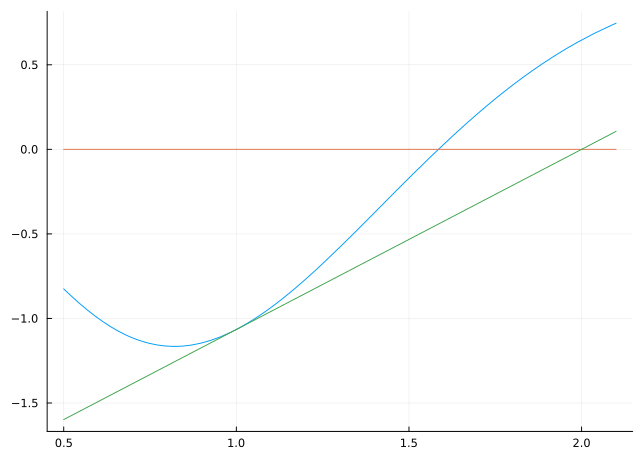

```julia
plot(f, .5, 2.1, legend=false)
plot!(zero)
plot!(tangent(f, c))
```

We could have defined `intersection_point` to accept a function with:

```
intersection_point(f, c) = c  - f(c)/Dc(f)(c)
```

Then this function could easily be reused for other problems.

### 6.4.2 Practice

#### Question

Let

```
f(x) = besselj(1, x)
```

This defines $f$ as a Bessel function of the first kind with order $\alpha=1$. Plot the approximate derivative over the interval $[0,5]$. There is one zero. What is its approximate value:

#### Question

Let $f(x) = \sin(\cos(x))$. Plot the approximate derivative of $f$. How many zeros are there between $5$ and $20$?

#### Question

Let $f(x) = |x^2 - 2|$. Plot the derivative of $f(x)$ over the interval $[-2,2]$. How many critical points do you see? (A critical point is where the derivative is $0$ *or* undefined.)

## 6.5 Automatic differentiation

We discuss now [Forward Mode Automatic Differentiation](http://en.wikipedia.org/wiki/Automatic_differentiation).

Automatic differentiation avoids the numeric instability issues of finite difference quotients by using a different approach. Whereas finite difference quotients have a long history, automatic differentiation only dates back to the 50s.

The `ForwardDiff` package implements automatic differentiation.

The `MTH229` package overloads the idea of `'`, to use automatic differentiation when the notation `f'` is encountered.

That means, we can find derivatives, as familiarly as:

```julia
f(x) = x^x
f'(1)
```

```
1.0
```

Here `f` is a function, `f'` is a derived function, and `f'(1)` is this derived function evaluated at `1`—just as with the use within a math text book.

Unlike, finite difference quotients automatic differentiation does not have issues arising from the loss of precision encountered when subtracting two like-sized numbers. Unlike symbolic derivatives (such as those found by the Wolfram Alpha website used by your iPhone’s Siri) they can be computed quickly, even if the computations defining the function involve many steps.

So what is automatic differentiation? The idea of the forward mode is quite intuitive. The *tangent line* approximation of a function at the point $c$ becomes

$$f(x) = f(c) + f'( c)(x-c) + O((x-c)^2)$$

Where the notation $O(x-c)^2$ means that the last term is not precisely spelled out, but is like some constant times the difference $(x-c)^2$. This has many applications, but for this one it reduces the knowledge of the function values at this level to two values $(f(c), f'(c))$

Now consider the product of two functions $f(x)$ and $g(x)$? The above formula applied to $f \cdot g$ is:

$$(f\cdot g)(x) = f(c) \cdot g(c) + (f'( c)g( c) + f( c)g'( c))(x-c) + O((x-c)^2)$$

This follows by the product rule. Again we have that two values determine the product $f\cdot g$ at this level, these being $(f(c) \cdot g(c)$, and $f'( c)g( c) + f( c)g'( c)$. *But*, this combination can be made from the values $(f(c), f'(c))$ and $(g(c), g'(c))$ which represent $f$ and $g$. Hence it is enough to know the two values for $f$ and $g$ to compute the two values for $f\cdot g$.

In fact, the rules of derivatives allow us to say the same for addition, subtraction, multiplication, division, powers *and* composition. For composition this is from the chain rule:

$$(f \circ g)(x) = (f \circ g)(c) + f'( g(c)) g'(c) (x-c) + O((x-c)^2).$$

Automatic differentiation can be implemented by extending how we store a value, storing both $(x, dx)$ as above. With this, the rules of differentials inform us how we combine these values. For example:

- $$(x, dx) + (y, dy) = (x + y, d(x+y)) = (x + y, 1dx + 1dy)$$
- $$(x, dx) \cdot (y, dy) = (xy, d(xy)) = (xy, y dx + x dy)$$
- $$(x, dx)^n = (x^n, d(x^n)) = (x^n, n x^{n-1} dx)$$

etc.

For functions we need to use the chain rule:

- $$f((x, dx)) = (f(x), d(f(x))) = (f(x), f'(x) dx )$$

### 6.5.1 Examples

Using `'`, we see that plotting a function and its derivative is straightforward:

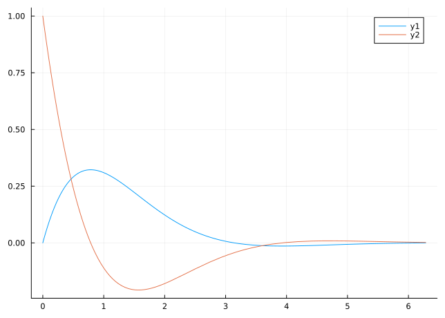

```julia
f(x) = exp(-x)*sin(x)
plot(f, 0, 2pi)
plot!(f')
```

Second derivatives are also available:

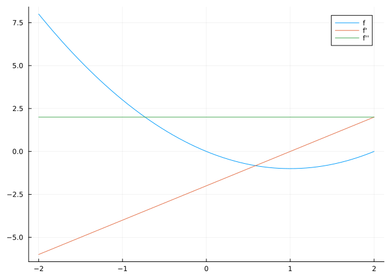

```julia
f(x) = x^2 - 2x
plot(f, -2, 2; label="f")
plot!(f'; label="f'")
plot!(f''; label="f''")
```

Here is an example where we plot the tangent line and the function. The `MTH229` package provides a function `tangent` which takes values for `f` and `c` and returns a *function* that represents the tangent line. The use is illustrated below. First we define a function `f` and use `tangent` to define a function `tl`:

```julia
f(x) = x^x
c = 1
tl = tangent(f, c)
```

```
Function of `x` to compute the tangent line of `f` at `c`:
    f(c) + f'(c) * (x-c)
```

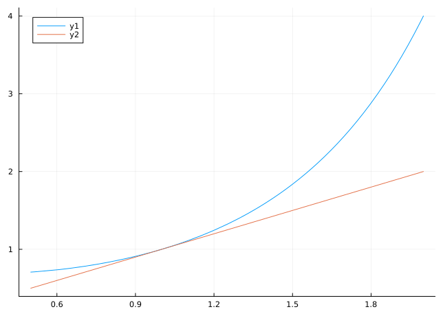

```julia
plot(f, 1/2, 2)
plot!(tl)     # or, more directly, plot!(tangent(f, c))
```

##### Example: AP Calculus question

The 2014 AP Calculus exam included this question:

Grass clippings are placed in a bin, where they decompose. For $0 \leq t \leq 30$, the amount of grass clippings remaining in the bin is modeled by $A(t) = 6.687(0.931)^t$. Where $A(t)$ is measured in pounds and $t$ is measured in days.

- Find the average rate of change of $A(t)$ over the interval of $0 \leq t \leq 30$. Indicate units of measure.
- Find the value of $A'(15)$. Using correct units, interpret the meaning of the value in the context of the problem.
- Find the time $t$ for which the amount of grass clippings in the bin is equal to the average amount of grass clippings in the bin over the interval $0 \leq t \leq 30$.
- For $t > 30$, $L(t)$, the linear approximation to $A$ at $t=30$ is a better model for the amount of grass clippings remaining in the bin. Use $L(t)$ to predict the time at which there will be 0.5% pound of grass clippings remaining in the bin. Show the work that leads to your answer.

We can do all this relatively quickly with the `fzero` function from the `Roots` package.

First, we define $A(t)$:

```julia
A(t) = 6.687 * (0.931)^t
```

```
A (generic function with 1 method)
```

The first question is answered by the slope of the secant line connecting $(0,A(0))$ and $(30, A(30))$:

```julia
m = (A(30) - A(0)) / (30 - 0)
```

```
-0.1968024043540685
```

The units are in pounds per day.

The second question is done through the derivative, as follows:

```julia
A'(15)
```

```
-0.1635905803884566
```

This also has units in pounds per day. This is the instantaneous rate of decomposition, and is less (in absolute value) than the average decay rate.

The mean value theorem tells us that there is at least one time where the instantaneous decomposition rate equals the average rate over the interval $[0,30]$. Thus the endpoints form a bracketing interval for the equation $A'(t) = m$, which we solve with:

```julia
aux(t) = A'(t) - m
fzero(aux, 0, 30)
```

```
12.414773526372592
```

So at $12.41\cdots$ days, the instantaneous rate is equal to the average rate of decomposition over the first 30 days.

But this doesn’t really answer the question asked, which is about the average amount of grass clippings in the bin. For this we need the integral form of the mean value theorem. Skipping ahead a few lessons to solve this problem, we have:

```julia
a, err = quadgk(A, 0, 30)   # area under A from 0,30
avg = a/(30-0)
eqn(t) = A(t) - avg
fzero(eqn, 0, 30)
```

```
12.414773526372596
```

We get the same answer—think about whether that is a coincidence.

Finally, we can define $L(t)$ using the point-slope form of the line. The point is $(30, A(30))$ and the slope is $A'(30)$:

```julia
L(t) = A(30) + A'(30) * (t - 30) # t > 30
```

```
L (generic function with 1 method)
```

We could restrict $L$ to insist that $t > 30$, but this isn’t necessary. We are asked to solve this. Using `fzero` requires a bracket. We check that $L(30) > 0.5$ and that $L(100)$ is negative:

```julia
L(30), L(100)
```

```
(0.7829278693779448, -3.135406990501517)
```

So, we can use $[30, 100]$ as a bracket for $L(t) - 0.5 = 0$:

```julia
eqn(t) = L(t) - 0.5
fzero(eqn, 30, 100)
```

```
35.054430405946825
```

So a bit over 35 days to decompose to half a pound.

Here is a picture, showing the decay:

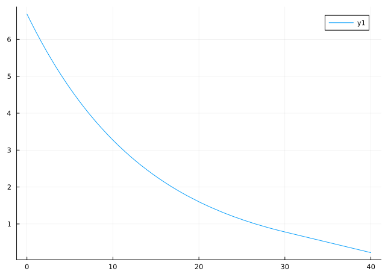

```julia
f(t) = t <= 30 ? A(t) : L(t)
plot(f, 0, 40)
```

### 6.5.2 Practice

#### Question

Which definition would be right for $(x,dx) - (y, dy)$ following the examples on forward mode automatic differentiation?

`(x - y, dx - dy)`

`(x - y, dx - y)`

`(x - dx, y - dy)`

#### Question: find tangent line intersection

Redefine `intersection_point` as:

```julia
intersection_point(f, c) = c - f(c)/f'(c)
```

```
intersection_point (generic function with 2 methods)
```

Now for $f(x) = 10/(1+x^2) - 10 \cdot \exp(-(1/2) \cdot x^2)$ and $c=1$ find the intersection point.

#### Question: what is the size of the error?

We can compare the error at many different points with the following construct

```julia
f(x)  = exp(-x) * sin(x)
df(x) = exp(-x) * (cos(x) - sin(x))
[abs(f'(x) - df(x) ) for x in range(0, pi, 25)]
```

What is the order (exponent) of the largest difference above?

`1e-10`

`1e-17`

`1e-14`

## 6.6 Error analysis

We end with a digression on how big `h` should be to have the approximate derivatives as close as can be.

The choice of $h$ in the derivative approximations above was done somewhat arbitrarily, with only the intuition that smaller $h$’s should produce more accurate approximations (which of course may be way off, as we are subtracting like-sized values in the derivative formula). Here we look a bit more closely at how to choose $h$.

As mentioned, with a bit of work from the second semester of calculus one can learn that the *mathematical error* in the forward difference quotient is “order $h$” whereas the mathematical error in the central difference quotient is “order $h^2$. This means that as $h$ gets small the approximation error in the first is a multiple of $h$, but for the second a multiple of $h^2$—a much smaller error in general.

However there is also error due to *floating point approximation*. Such error is different in that it gets bigger as $h$ gets smaller. So one error gets bigger, the other gets smaller. So clearly if $h$ gets too small, the floating point error will dominate and the overall error will not get smaller, rather larger.

So, how big is the floating point error? For any given number, it can be roughly as big as the the machine precision amount, $\epsilon$. So in the forward-difference quotient approximation we could have errors in both terms $f(x+h)$ and $f(x)$ so the total error could be as big as $2\epsilon$. But this is divided by $h$ as we have:

$$\frac{f(x+h) - f(x)}{h} = \frac{float(f(x +h)) + \epsilon - float(f(x_) + \epsilon}{h} =
\frac{float(f(x+h))-float(f(x))}{h} + \frac{2\epsilon}{h}.$$

The errors may or *may not* cancel so the algebra with $\epsilon$ is unusual to the untrained eye. It basically takes into account the worse case.

The key is the $2\epsilon/h$ term—it gets bigger as $h$ gets smaller.

So if each floating point approximation is no more off than $\epsilon$, we have this bound on the error:

$$\text{error} \leq \frac{2\epsilon}{h} + (M/2)h$$

Where $M$ is a constant that depends on the maximum absolute value of the second derivative and the $1/2$ comes from second semester calculus. Choosing $h$ to make this as small as possible is possible with some calculus involving the derivative, but for now we simply note the answer is $h=((2\epsilon)/(M/2))^{1/2} = 2\sqrt{\epsilon}/\sqrt{M}$.

Taking $\epsilon$ as machine tolerance and (conveniently) $M=1$ we get

$$h_{min} = 2\sqrt{epsilon}/1 \approx 10^{-8}$$

Or more precisely:

```julia
2 * sqrt(eps())
```

```
2.9802322387695312e-8
```

We can check this is about right, by graphing on a different scale:

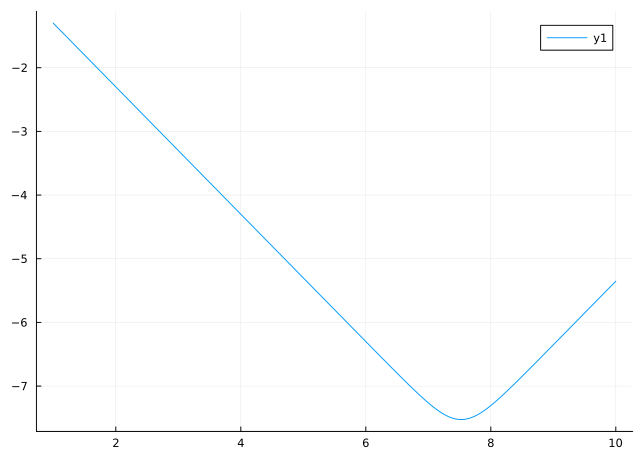

```julia
f(h; M=1) = 2*eps()/h + (M/2)*h
g(x) = log10(f(10.0^(-x)))
plot(g, 1, 10)          # min near 8, which means h like 1e-8
```

Numerically, we can check how this basically works for some test function:

```julia
f(x) = exp(x) - x^3
df(x) = exp(x) - 3x^2
[hs [Df(f,h=h)(.5) - df(.5) for h in hs] ]
```

```
16×2 Matrix{Float64}:
 0.1      -0.074746
 0.01     -0.00682885
 0.001    -0.000676365
 0.0001   -6.75712e-5
 1.0e-5   -6.75649e-6
 1.0e-6   -6.75645e-7
 1.0e-7   -6.65768e-8
 1.0e-8    4.47752e-9
 1.0e-9   -1.73158e-7
 1.0e-10  -1.73158e-7
 1.0e-11   4.26773e-6
 1.0e-12  -0.000106755
 1.0e-13   0.000559379
 1.0e-14  -0.0105429
 1.0e-15  -0.0105429
 1.0e-16   1.32172
```

We see the best case is around $h=10^{-8}$, as expected by the theory.

### 6.6.1 Approximation errors for the central difference quotient

For the central difference quotient, the errors are different. The error in $h$ becomes:

$$\text{error} \leq (2\epsilon)/(2h) + (M/6) h^2$$

This gives $(3\epsilon/M)^{1/3}$ as the choice for $h$ that minimizes the right-hand expression.

Taking $\epsilon$ as the machine tolerance and (conveniently) $M=3$ we get

$$h_{min} \approx 10^{-6}$$

We can again check how this works for our function and point:

```julia
[hs [ Dc(f,h=h)(.5) - fp(.5) for h in hs] ]
```

```
16×2 Matrix{Float64}:
 0.1      -0.00725075
 0.01     -7.25139e-5
 0.001    -7.1796e-7
 0.0001   -1.11022e-16
 1.0e-5    7.1676e-9
 1.0e-6    7.28972e-9
 1.0e-7    7.28972e-9
 1.0e-8    1.17306e-8
 1.0e-9   -5.48828e-8
 1.0e-10  -1.65905e-7
 1.0e-11   4.27499e-6
 1.0e-12  -0.000106747
 1.0e-13   0.000559386
 1.0e-14  -0.0105428
 1.0e-15   0.100479
 1.0e-16   1.32172
```

### 6.6.2 Practice

#### Question: best depends on the function and value

A subtle point above is that we are minimizing an upper bound in $h$ with an assumption, not the actual error. The actual answer may differ as it depends on a function and the point of evaluation. Look at the function $f(x) = x^2 - 2x$ and compare the values at $0.5$ as above:

```julia
hs = [(1/10)^i for i in 1:16]
f(x) = x^2 - 2x
df(x) = 2x - 2
[hs [Dc(f,h=h)(.5) - df(.5) for h in hs] ]
```

```
16×2 Matrix{Float64}:
 0.1       2.22045e-16
 0.01     -6.66134e-16
 0.001    -6.66134e-16
 0.0001    1.10356e-13
 1.0e-5   -9.99645e-13
 1.0e-6   -2.87552e-11
 1.0e-7   -2.87552e-11
 1.0e-8   -5.02476e-9
 1.0e-9   -2.72292e-8
 1.0e-10  -8.27404e-8
 1.0e-11  -8.27404e-8
 1.0e-12   2.21217e-5
 1.0e-13   0.000244166
 1.0e-14   0.000799278
 1.0e-15   0.000799278
 1.0e-16  -0.110223
```

What is the best value of $h$?

For which of these values of $h$ is the error smallest?

`1e-3`

`1e-6`

`1e-8`

`1e-12`

#### Question: error analysis

Consider these commands:

```julia
f(x) = sin(x)
df(x) = cos(x)
[hs [ Dc(f,h=h)(.5) - df(.5) for h in hs] ]
```

Do they show the smallest error around $10^{-6}$ as expected?

true

false

## 6.7 Symbolic derivatives

The `SymPy` package can differentiate a symbolic expression and return a symbolic expression, similar to what one would get by hand.

The key function is `diff(ex)` or `diff(ex, x)` when specifying which variable to differentiate in is needed. Higher order derivatives can be computed by repeating the variable (eg. `diff(ex, x, x)`) or specifying a number after the variable (eg. `diff(ex, x, 2)`),

Consider the function $f(x) = x \cdot \tanh(\exp(x))$. We define it and then create a symbolic expression:

```julia
@syms x
f(x) = x * tanh(exp(x))
ex = f(x)
```

\[ x \tanh{\left(e^{x} \right)} \]

This expression has first and second derivatives computed by:

```julia
diff(ex, x)
```

\[ x \left(1 - \tanh^{2}{\left(e^{x} \right)}\right) e^{x} + \tanh{\left(e^{x} \right)} \]

and

```julia
diff(ex, x, x)
```

\[ \left(x \left(2 e^{x} \tanh{\left(e^{x} \right)} - 1\right) - 2\right) \left(\tanh^{2}{\left(e^{x} \right)} - 1\right) e^{x} \]

If there are one or more parameters, the variable must be specified.

```julia
@syms a0 a1 a2 a3 x
p = a0 + a1*x + a2*x^2 + a3*x^3
```

\[ a_{0} + a_{1} x + a_{2} x^{2} + a_{3} x^{3} \]

```julia
diff(p, x)   # diff(p) will error
```

\[ a_{1} + 2 a_{2} x + 3 a_{3} x^{2} \]

**NoteEnvironment of `Julia` when generated**

`Julia` version:

```julia
VERSION
```

```
v"1.12.6"
```

Packages and versions:

```julia
using Pkg
Pkg.status()
```

```
Status `~/work/mth229.github.io/mth229.github.io/Project.toml`
  [a2e0e22d] CalculusWithJulia v0.3.2
  [7073ff75] IJulia v1.34.4
  [b964fa9f] LaTeXStrings v1.4.0
  [ebaf19f5] MTH229 v0.3.2
  [91a5bcdd] Plots v1.41.6
  [f27b6e38] Polynomials v4.1.1
  [438e738f] PyCall v1.96.4
  [612c44de] QuizQuestions v0.3.27
  [295af30f] Revise v3.14.2
⌅ [f2b01f46] Roots v2.3.0
  [24249f21] SymPy v2.3.3
  [56ddb016] Logging v1.11.0
Info Packages marked with ⌅ have new versions available but compatibility constraints restrict them from upgrading. To see why use `status --outdated`
```